# 2018_midterm_Stroud

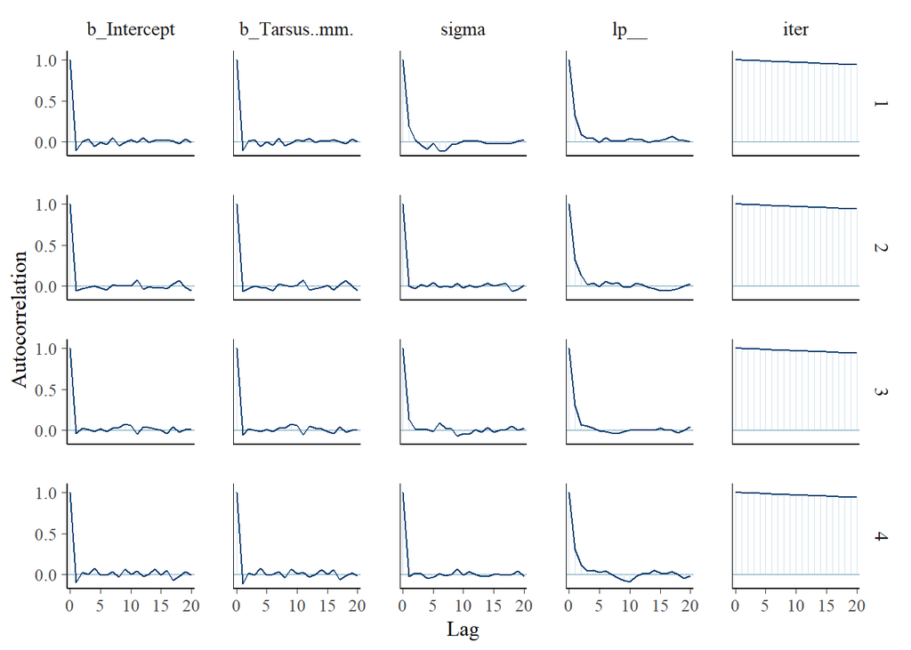

```r
mcmc_acf(morph_posterior) #also looks good, convergering
```

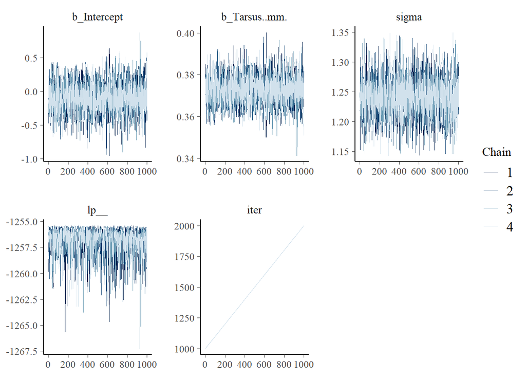

```r
morph_fit <- fitted(morph_bay_mod) %>% as.data.frame()
morph_res <- residuals(morph_bay_mod) %>% as.data.frame()
mcmc_trace(morph_posterior)
```

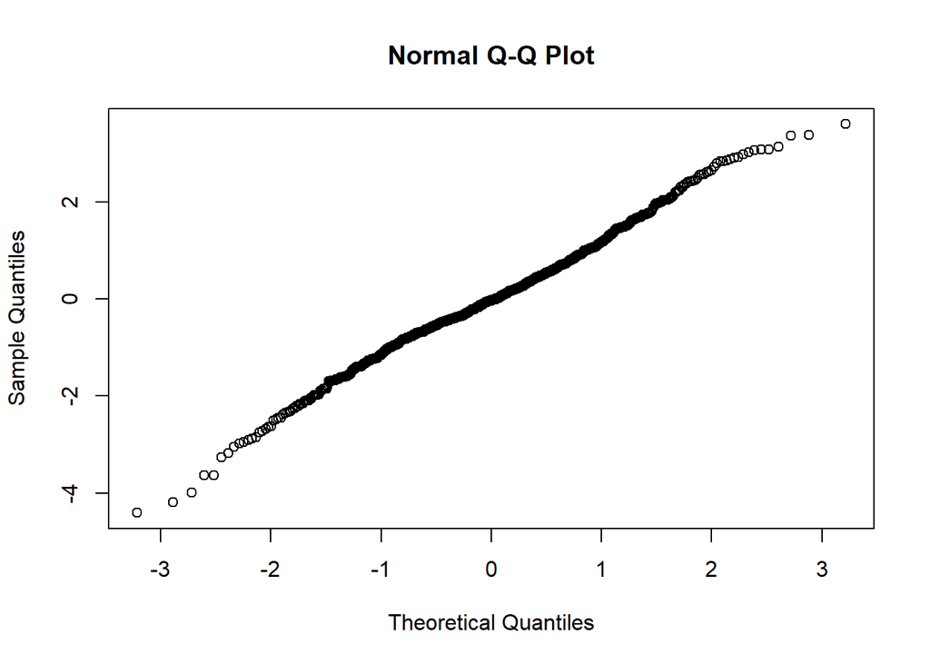

```r
qqnorm(morph_res$Estimate) #looks good
```

```r
pp_check(morph_bay_mod, type= "scatter") #no pathological diversions
```

```
## Using 10 posterior samples for ppc type 'scatter' by default.
```

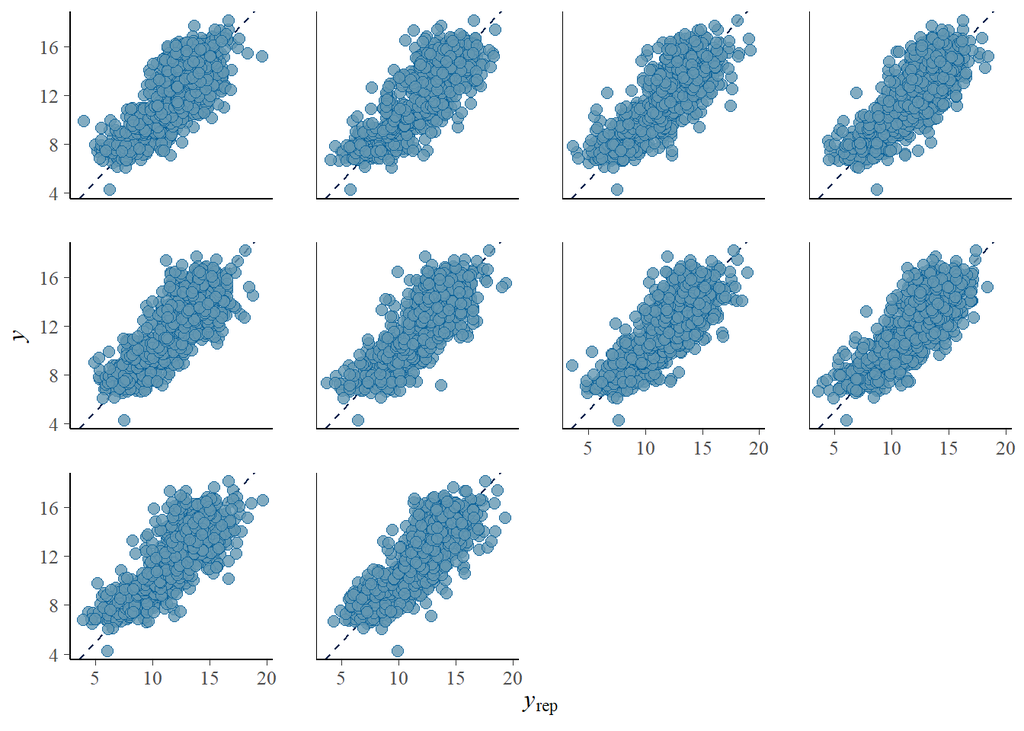

```r
pp_check(morph_bay_mod, type = "dens")
```

```
## Using 10 posterior samples for ppc type 'dens' by default.
```

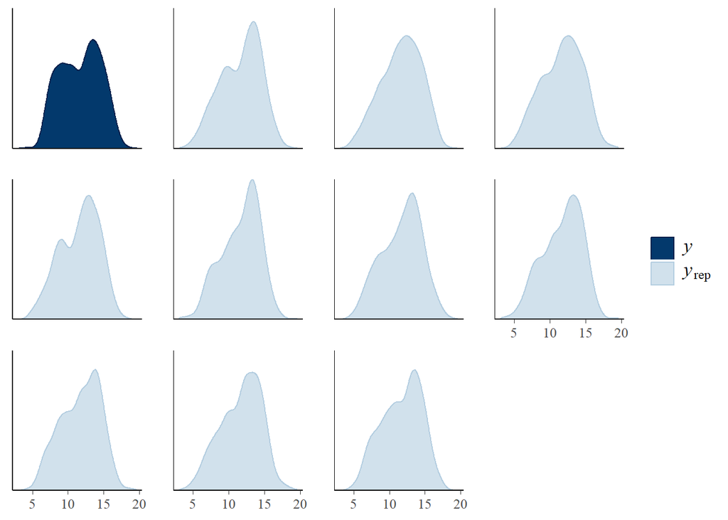

```r
pp_check(morph_bay_mod, type = "stat", stat = "mean")
```

```
## Using all posterior samples for ppc type 'stat' by default.
```

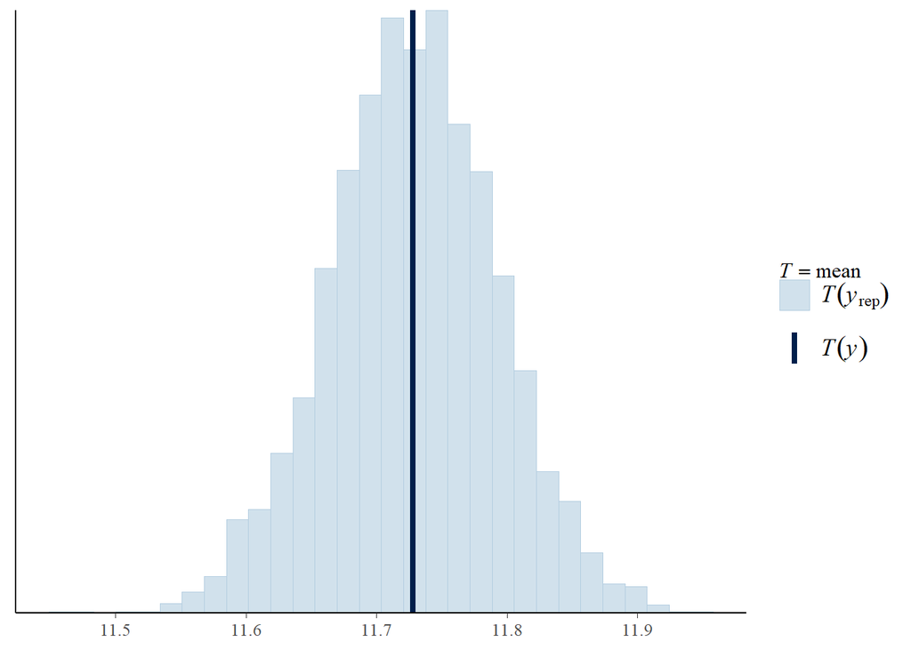

```r
pp_check(morph_bay_mod, type = "stat_2d")
```

```
## Using all posterior samples for ppc type 'stat_2d' by default.
```

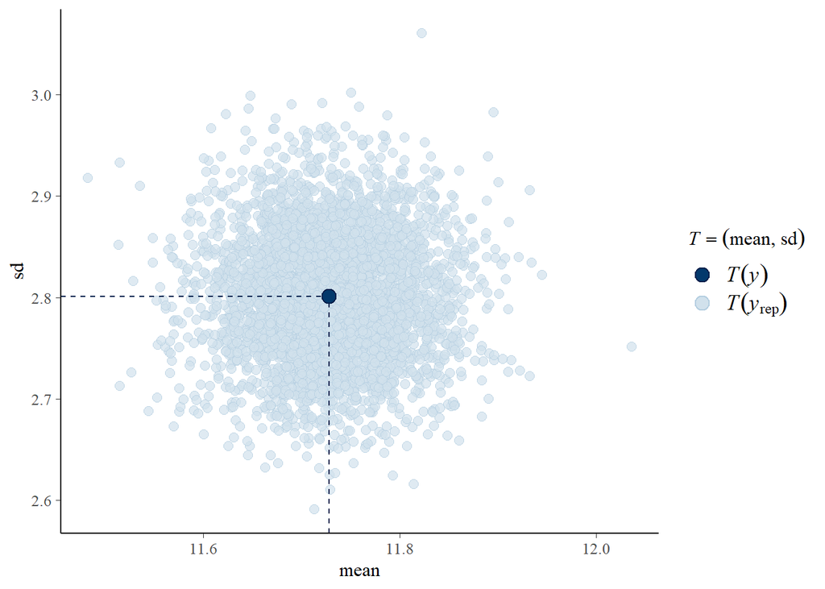

5.2 Three interpretations (10 points) OK, now that we have fits, take a look! Do the coefficients and their associated measures of error in their estimation match? How would we interpret the results from these different analyses differently? Or would we? Note, confint works on lm objects as well.

```r
library(tidyverse)
#least squares linear regression
summary(morph_mod)%>% broom::tidy()
```

```
## # A tibble: 2 x 5
##   term              estimate std.error statistic   p.value
##   <chr>                <dbl>     <dbl>     <dbl>     <dbl>
## 1 (Intercept)        -0.0987   0.215      -0.458 6.47e-  1
## 2 morph$Tarsus..mm.   0.373    0.00665    56.1   3.24e-273
```

```r
confint(morph_mod)
```

```
##                        2.5 %    97.5 %
## (Intercept)       -0.5216505 0.3242363
## morph$Tarsus..mm.  0.3598809 0.3859727
```

```r
#likelihood   #what about residual se?
morph_glm
```

```
##
## Call:  glm(formula = Culmen..mm. ~ Tarsus..mm., family = gaussian(link = "identity"),
##     data = morph)
##
## Coefficients:
## (Intercept)  Tarsus..mm.
##    -0.09871      0.37293
##
## Degrees of Freedom: 765 Total (i.e. Null);  764 Residual
## Null Deviance:       6001
## Residual Deviance: 1172  AIC: 2505
```

```r
confint(morph_glm)
```

```
##                  2.5 %    97.5 %
## (Intercept) -0.5209805 0.3235663
## Tarsus..mm.  0.3599015 0.3859520
```

```r
#Baysian
summary(morph_bay_mod, digits= 4)  #so far so good
```

```
##  Family: gaussian
##   Links: mu = identity; sigma = identity
## Formula: Culmen..mm. ~ Tarsus..mm.
##    Data: morph (Number of observations: 766)
## Samples: 4 chains, each with iter = 2000; warmup = 1000; thin = 1;
##          total post-warmup samples = 4000
##
## Population-Level Effects:
##             Estimate Est.Error l-95% CI u-95% CI Eff.Sample Rhat
## Intercept      -0.09      0.22    -0.51     0.33       4344 1.00
## Tarsus..mm.     0.37      0.01     0.36     0.39       4630 1.00
##
## Family Specific Parameters:
##       Estimate Est.Error l-95% CI u-95% CI Eff.Sample Rhat
## sigma     1.24      0.03     1.18     1.31       3400 1.00
##
## Samples were drawn using sampling(NUTS). For each parameter, Eff.Sample
## is a crude measure of effective sample size, and Rhat is the potential
## scale reduction factor on split chains (at convergence, Rhat = 1).
```

All three generate a relationship where tarsus predicts culmen length. But they take very different approaches. In least squares, we use test statistics from Frequentist theory where we could confidently reject the null (the probably there was no relationship). Likelihood approaches this questsion by looking at the probabiliy of getting our data for all parameters (in a given range). This approach evauluates multiple hypothesis not just comparing ours to a null like above. Like least squares it still looks at the probability fo the data given the hypothesis.  
With a Bayesian approach we can flip the relationship and examine the probability of our hypothesis given the data. It incorporates prior knowledge of the relationship into the model and allows us to assert a degree of belief in the probability of a hypothesis being true.

### 5.3 Everyday I’m Profilin’ (10 points)For your likelihood fit, are your profiles well behaved? For just the slope, use grid sampling to create a profile. You’ll need to write functions for this, and use the results from your glm() fit to provide the reasonable bounds of what you should be profiling over (3SE should do). Is it well behaved? Plot the profile and give the 80% and 95% CI. Verify your results with profileModel.

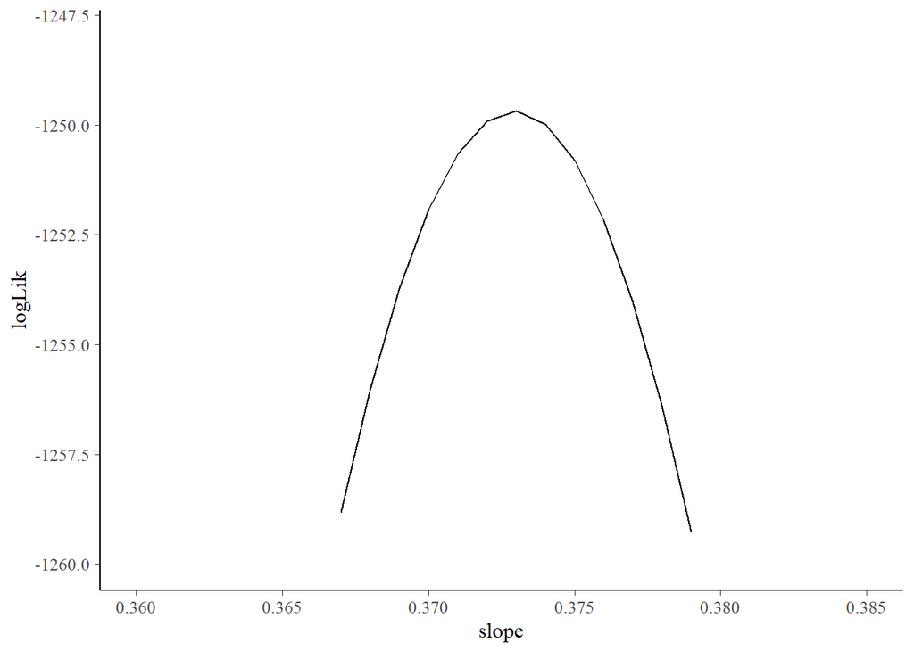

```r
#grid sampling
lik_fun <- function(slope, intercept, resid_sd){
  #data generating process
 cul_fit <- intercept + slope * morph$Tarsus..mm.

  #likelihood
  sum(dnorm(morph$Culmen..mm., cul_fit, resid_sd, log=TRUE))
}

gs_loglik <- crossing(intercept = -0.098707,
                      slope = seq(0.28,0.48,.001),
                       resid_sd = seq(.5, 1.5, .01)) %>%
  rowwise() %>%
  mutate(logLik = lik_fun(slope, intercept, resid_sd)) %>%
  ungroup()
#filter for max loglik
slope_prof <-gs_loglik %>% group_by(slope) %>%
  filter(logLik == max(logLik))

prof_plot <- ggplot(data = slope_prof, aes(x= slope, y=logLik))  + geom_line() +  xlim(0.36,0.385)+ ylim(-1260,-1248) #zoomed in after viewing
prof_plot
```

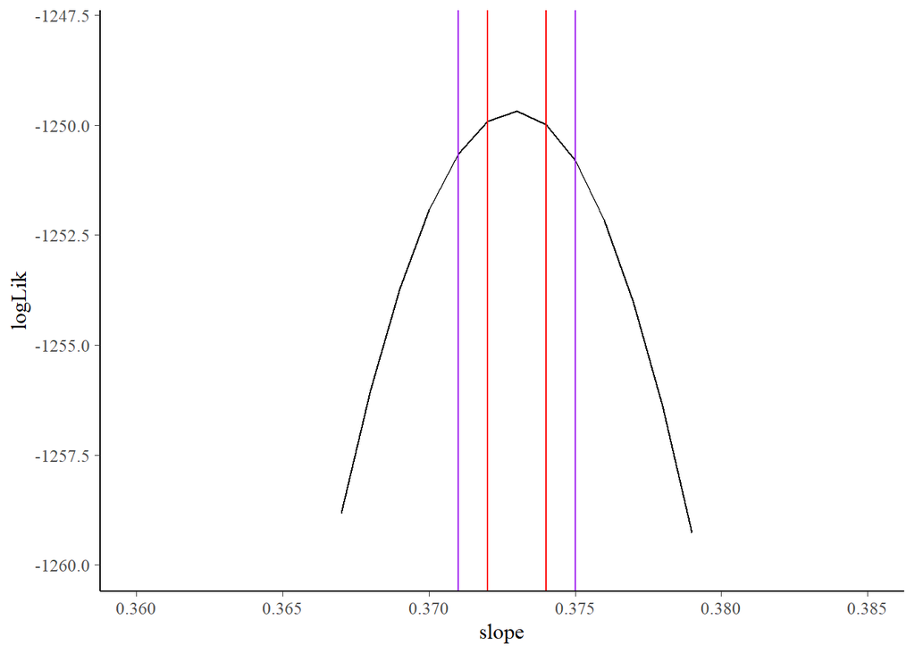

```r
#95 CI
CI_95 <- gs_loglik %>%
filter(logLik > max(logLik) - 1.96) %>%
  arrange(slope) %>%
  filter(row_number()==1 | row_number()==n())%>%
  as.data.frame()

#80 CI
CI_80 <- gs_loglik %>% filter(logLik > max(logLik) - 1.642/2) %>%
  arrange(slope) %>%
  filter(row_number()==1 | row_number()==n())%>%
  as.data.frame()

prof_plot + geom_vline(xintercept =0.372 , color="red")+ geom_vline(xintercept = 0.374, color= "red")+
  geom_vline(xintercept= 0.371, color= "purple")+ geom_vline(xintercept = 0.375, color= "purple")
```

```r
#compare to profileModel/ sanity check
prof_glm_95 <- profileModel(morph_glm,
                         objective="ordinaryDeviance",
                         quantile= qchisq(0.95, 1))
```

```
## Preliminary iteration .. Done
##
## Profiling for parameter (Intercept) ... Done
## Profiling for parameter Tarsus..mm. ... Done
```

```r
prof_glm_80 <- profileModel(morph_glm,
                         objective="ordinaryDeviance",
                         quantile= qchisq(0.80, 1))
```

```
## Preliminary iteration .. Done
##
## Profiling for parameter (Intercept) ... Done
## Profiling for parameter Tarsus..mm. ... Done
```

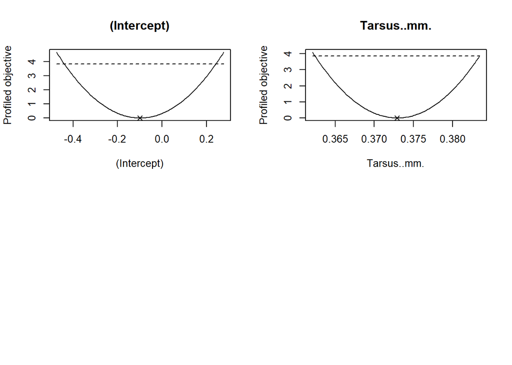

```r
plot(prof_glm_95)
```

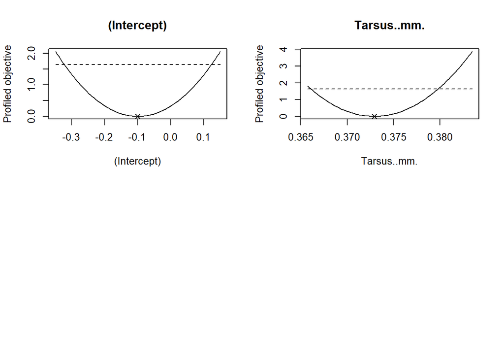

```r
plot(prof_glm_80)
```